# Homework 2

CHAN Pok Wah

Note that some of the code blocks in this assignment contain the expression `eval = FALSE`. This tells R Markdown to display the code contained in the block, but not to evaluate it. Remove it if you want to turn off this behavior.

### Problem 1: `table()`, `tapply()`

The `MASS` package contains a dataset called `Insurance`. Type `?Insurance` in your console to take a look at its help document.

```r
library(MASS)
head(Insurance)
```

```
##   District  Group   Age Holders Claims
## 1        1    <1l   <25     197     38
## 2        1    <1l 25-29     264     35
## 3        1    <1l 30-35     246     20
## 4        1    <1l   >35    1680    156
## 5        1 1-1.5l   <25     284     63
## 6        1 1-1.5l 25-29     536     84
```

##### (a) `table()`

Use the `table()` function to produce a contingency table of observation counts across District and Age.

```r
table(Insurance$District, Insurance$Age)
```

```
##
##     <25 25-29 30-35 >35
##   1   4     4     4   4
##   2   4     4     4   4
##   3   4     4     4   4
##   4   4     4     4   4
```

##### (b) `tapply()`

Use the `tapply()` function to show the average number of Holders across District and Age categories.

```r
# Insert your code here
tapply(Insurance$Holders, list(Insurance$District, Insurance$Age), mean)
```

```
##      <25  25-29  30-35    >35
## 1 159.50 289.25 349.00 1838.5
## 2  77.25 168.75 215.75 1201.5
## 3  29.75  83.75 123.25  805.0
## 4  18.00  42.25  63.75  374.5
```

##### (c) Total number of Holders by District and Age

Use the `tapply()` function to show the total number of Holders across District and Age.

```r
# Insert your code here
tapply(Insurance$Holders, list(Insurance$District, Insurance$Age), sum)
```

```
##   <25 25-29 30-35  >35
## 1 638  1157  1396 7354
## 2 309   675   863 4806
## 3 119   335   493 3220
## 4  72   169   255 1498
```

##### (d) Total number of Claims by District and Age

Use the `tapply()` function to show the total number of Claims across District and Age.

```r
# Insert your code here
tapply(Insurance$Claims, list(Insurance$District, Insurance$Age), sum)
```

```
##   <25 25-29 30-35 >35
## 1 124   189   202 866
## 2  65   131   122 573
## 3  26    56    79 392
## 4  14    28    50 234
```

##### (e) The rate of Claims per Holder by District and Age

Use your answers from parts (c) and (d) to calculate the rate of Claims per Holder across District and Age.

```r
# Insert your code here
tapply(Insurance$Claims, list(Insurance$District, Insurance$Age), sum) / tapply(Insurance$Holders, list(Insurance$District, Insurance$Age), sum)
```

```
##         <25     25-29     30-35       >35
## 1 0.1943574 0.1633535 0.1446991 0.1177590
## 2 0.2103560 0.1940741 0.1413673 0.1192260
## 3 0.2184874 0.1671642 0.1602434 0.1217391
## 4 0.1944444 0.1656805 0.1960784 0.1562083
```

*Tip: if an insurance company has 120,000 policy holders and receives 14,000 claims, the rate of claims per holder is 14000/120000 = 0.117.*

### Problem 2: Computing and plotting trimmed means

##### (a) Writing a function for calculating the trimmed mean

Write a function that calculates the mean of a numeric vector `x`, ignoring the `s` smallest and `l` largest values (this is a trimmed mean).

E.g., if `x = c(1, 7, 3, 2, 5, 0.5, 9, 10)`, `s = 1`, and `l = 2`, the function would return the mean of `c(1, 7, 3, 2, 5)` (this is `x` with the 1 smallest value (0.5) and the 2 largest values (9, 10) removed).

The function should use the `length()` function to check if x has at least `s + l + 1` values. If `x` is shorter than `s + l + 1`, the function should use the `message()` function to tell the user that the vector can’t be trimmed as requested. Check the help document if you don’t know the usage of `message()` (`?message`). ast If `x` has at least a length of `s + l + 1`, your function should return the trimmed mean.

```r
# here's a function skeleton to get you started
# fill me in with an informative comment
# describing what the function does
trimmedMean <- function(x, s = 0, l = 0) {
  i = 0
  oriLength = length(x)
  while (i < s) {
    x = x[x!=min(x)]
    i = i + 1
  }
  i = 0
  while (i < l) {
    x = x[x!=max(x)]
    i = i + 1
  }
  if (oriLength != length(x) + s + l) {
    message("This Vector can't be trimmed as requested")
  } else {
      return(x)
  }
# Insert your code here
}
trimmedMean(c(1,7,3,2,5,0.5, 9, 10), 1, 2)
```

```
## [1] 1 7 3 2 5
```

*Tip: it will be useful to recall the `sort()` function that we have used in lectures.*

Note: The `s = 0` and `l = 0` specified in the function definition are the default settings. i.e., this syntax ensures that if s and l are not provided by the user, they are both set to 0. Thus the default behaviour is that the `trimmedMean` function doesn’t trim anything, and hence is the same as the `mean` function.

##### (b) Applying the function with `mapply()`

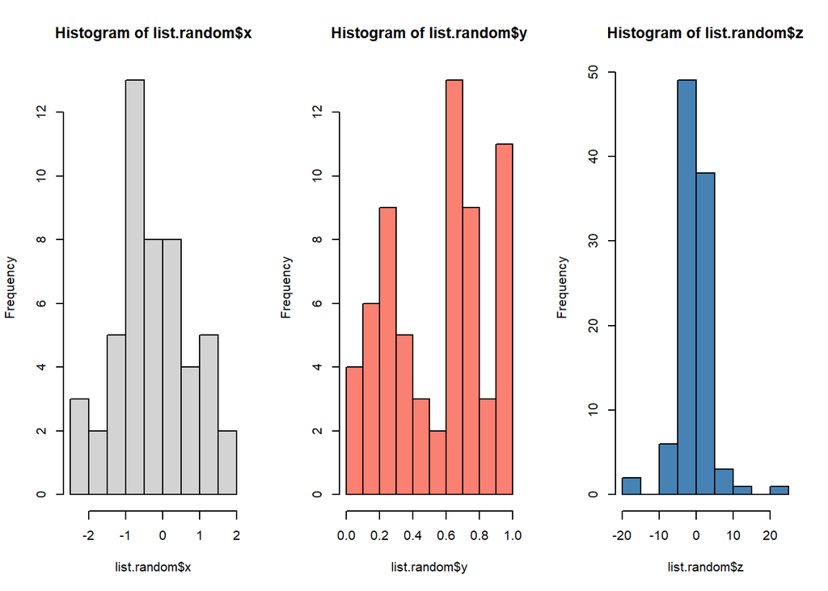

```r
# sets seed to make sure everyone's random vectors are generated the same
set.seed(201611)
list.random <- list(x = rnorm(50), y = runif(65), z = rt(100, df = 1.5))

# here's a figure showing histograms of the data
par(mfrow = c(1,3))
histx<-hist(list.random$x, col = 'lightgrey')
histy<-hist(list.random$y, col = 'salmon')
histz<-hist(list.random$z, col = 'steelblue')
```

Now `histx`, `histy`, and `histz` contain the respective information about the three histograms. For example, printing `histx` gives

```r
print(histx)
```

```
## $breaks
##  [1] -2.5 -2.0 -1.5 -1.0 -0.5  0.0  0.5  1.0  1.5  2.0
##
## $counts
## [1]  3  2  5 13  8  8  4  5  2
##
## $density
## [1] 0.12 0.08 0.20 0.52 0.32 0.32 0.16 0.20 0.08
##
## $mids
## [1] -2.25 -1.75 -1.25 -0.75 -0.25  0.25  0.75  1.25  1.75
##
## $xname
## [1] "list.random$x"
##
## $equidist
## [1] TRUE
##
## attr(,"class")
## [1] "histogram"
```

, and the `counts` component gives the number of observations falling in each bin of histogram `histx`:

```r
histx$counts
```

```
## [1]  3  2  5 13  8  8  4  5  2
```

Using the `mapply` functions with the function from part (a), create a list whose components are the trimmed means of the vectors in `list.random`, taking `s = the number of observations in the first bin` and `l = the number of observations in the last bin`.

```r
# Insert your code here
mapply(trimmedMean, list.random, MoreArgs = list(s = histx$counts[1], l = histx$counts[length(histx)]))
```

```
## $x
##  [1] -0.045636322 -0.869210149 -0.717093955  0.009025372 -0.433905009
##  [6] -0.230699589 -0.572019825 -0.922471758 -0.875003600  0.737131937
## [11] -0.012772120 -0.824755042 -1.091916045 -0.814865371 -1.949990219
## [16] -0.893452304  0.041932877 -0.476485655  0.330724567  0.415137914
## [21]  0.554512675 -1.014654495 -1.091248381  0.147308581 -0.373625172
## [26] -0.409487214 -0.848422638  0.288434791 -1.521304752 -0.763925956
## [31] -1.072996723 -0.684976446 -0.763804745  0.591493419 -0.352452218
## [36] -0.627457875 -1.266415002  0.404121979  0.224888147
##
## $y
##  [1] 0.68442456 0.28433519 0.71312305 0.29201701 0.90425762 0.29593788
##  [7] 0.46051840 0.33069249 0.70052335 0.23280447 0.18865755 0.38915715
## [13] 0.29565636 0.25503146 0.27202461 0.10753254 0.36872596 0.69681536
## [19] 0.73336023 0.79550911 0.72152471 0.35801309 0.60562230 0.63402890
```

[output cut: 25 more lines]

```r
#mapply(trimmedMean, list.random, histx$counts[1], histx$counts[length(histx)])  #Same Ans.
```

## Problem 3: Practicing the split-apply-combine pattern with the `strikes` data

```r
strikes.df <- read.csv("https://drive.google.com/uc?export=download&id=1nT40HPs_OTUqELnlVzjNTaxpOJf8VdYs")
dim(strikes.df)
```

```
## [1] 625   8
```

```r
summary(strikes.df)
```

```
##       country         year      strike.volume     unemployment
##  Australia: 35   Min.   :1951   Min.   :   0.0   Min.   : 0.000
##  Austria  : 35   1st Qu.:1959   1st Qu.:  19.0   1st Qu.: 1.200
##  Canada   : 35   Median :1968   Median : 127.0   Median : 2.500
##  Denmark  : 35   Mean   :1968   Mean   : 288.7   Mean   : 3.555
##  Finland  : 35   3rd Qu.:1977   3rd Qu.: 360.0   3rd Qu.: 5.500
##  France   : 35   Max.   :1985   Max.   :5918.0   Max.   :17.000
##  (Other)  :415
##    inflation      left.parliament centralization        density
##  Min.   :-2.900   Min.   : 8.16   Min.   :0.000005   Min.   :13.60
##  1st Qu.: 2.700   1st Qu.:32.20   1st Qu.:0.248274   1st Qu.:32.52
##  Median : 4.800   Median :42.50   Median :0.379830   Median :42.00
##  Mean   : 5.957   Mean   :40.85   Mean   :0.456375   Mean   :44.98
##  3rd Qu.: 8.200   3rd Qu.:49.70   3rd Qu.:0.749203   3rd Qu.:58.10
##  Max.   :27.500   Max.   :78.70   Max.   :0.999788   Max.   :81.30
##                                                      NA's   :179
```

##### (a) Splitting `strikes.df` by country

Use the `split()` function. Call the resulting list `strikes.by.country`, and show the names of elements of the list, as well as the first 5 rows of the data frame for Canada.

```r
# Insert your code here
strikes.by.country <- split(strikes.df, strikes.df$country)
head(strikes.by.country$Canada, 5)
```

```
##     country year strike.volume unemployment inflation left.parliament
## 101  Canada 1951           242          2.4      10.4            78.7
## 102  Canada 1952          5918          2.9       2.5            78.7
## 103  Canada 1953           335          2.9      -0.9            73.5
## 104  Canada 1954           372          4.5       0.6            73.5
## 105  Canada 1955           454          4.3       0.2            73.5
##     centralization density
## 101   0.0002251271      NA
## 102   0.0002155375      NA
## 103   0.0008731167      NA
## 104   0.0044578216      NA
## 105   0.0046760225      NA
```

##### (b) Computing the average unemployment rate for each country

Use `strikes.by.country` and `sapply()`, compute the average unemployment rate for each country.

```r
# Insert your code here
newMean <- function(x) {
  mean(x$unemployment)
}
sapply(strikes.by.country, newMean)
```

```
##   Australia     Austria     Belgium      Canada     Denmark     Finland
##   3.5057143   2.5400000   3.6466667   6.0428571   5.7114286   2.5714286
##      France     Germany     Ireland       Italy       Japan Netherlands
##   3.1828571   3.1171429   7.7714286   6.7257143   1.6028571   3.6914286
## New.Zealand      Norway      Sweden Switzerland          UK         USA
##   1.0028571   1.4285714   2.1371429   0.3285714   3.4514286   5.5428571
```

##### (c) What country has the highest average unemployment rate? The lowest?

The Ireland has the highest average unemployment rate. The switzerland has the lowest average unemployment rate.

##### (d) Using `sapply()` to compute multiple avarages

Using `strikes.by.country` and just one call to `sapply()`, compute the average unemployment rate, inflation rates, and strike volume for each country. The output should be a matrix of dimension 3 x 18. Also, with just the one call to `sapply()`, figure out how to make the output matrix have appropriate row names.

```r
# Insert your code here
newerMean <- function(x) {
  return(list(Avg.UR = mean(x$unemployment), Avg.IR = mean(x$inflation), Avg.SV = mean(x$strike.volume)))
}
sapply(strikes.by.country, newerMean)
```

```
##        Australia Austria  Belgium  Canada   Denmark  Finland  France
## Avg.UR 3.505714  2.54     3.646667 6.042857 5.711429 2.571429 3.182857
## Avg.IR 6.594286  5.102857 4.15     4.797143 6.582857 7.317143 6.948571
## Avg.SV 378.6     25.6     244      749.5429 194.8286 448.5429 185.4
##        Germany  Ireland  Italy    Japan    Netherlands New.Zealand
## Avg.UR 3.117143 7.771429 6.725714 1.602857 3.691429    1.002857
## Avg.IR 3.294286 8.151429 8.005714 5.82     4.814286    7.691429
## Avg.SV 43.82857 547.4286 997.6857 165.8286 26.11429    259.2571
##        Norway   Sweden   Switzerland UK       USA
## Avg.UR 1.428571 2.137143 0.3285714   3.451429 5.542857
## Avg.IR 6.32     6.434286 3.417143    7.105714 4.428571
## Avg.SV 75.11429 73.48571 3.657143    322.7143 448.2286
```

## Problem 4: Rewrite a `for` loop with the `tapply()` function

The following code implements the k-fold cross validation with a `for` loop. Rewrite the code between the lines of hashtags using `tapply()`.

```r
default.data <- read.csv("https://drive.google.com/uc?export=download&id=1iTmjYcOf7cmnQz76Rart9ZbJGrhl7QXk")
set.seed(1)

#######################

partition <- (1:nrow(default.data)) %% 10 + 1 # k = 10
fold <- sample(partition, length(partition))

logistic.fit <- vector("list", 10)
logistic.prob <- vector("numeric", 10000)

for (i in 1:10) {
  logistic.fit[[i]] <- glm(default ~ student + balance, family = binomial, data = default.data[fold!= i,])
  logistic.prob[fold == i] <- predict(logistic.fit[[i]], default.data[fold==i, ],  type="response")
}
str(logistic.prob)
```

```
##  num [1:10000] 0.001464 0.001123 0.009315 0.000474 0.002038 ...
```

```r
#######################
```

```r
# Said by Dr. Jia, this format is acceptable as a result.

result <- tapply(1:nrow(default.data), fold, function(x) {
  temp <- glm(default ~ student + balance, family = binomial, data = default.data[-x,])
  predict(temp, default.data[x,], type="response")
})
str(result)
```

```
## List of 10
##  $ 1 : Named num [1:1000] 0.000474 0.002027 0.000118 0.012006 0.000298 ...
##   ..- attr(*, "names")= chr [1:1000] "4" "6" "16" "20" ...
##  $ 2 : Named num [1:1000] 1.12e-03 5.84e-05 3.33e-03 1.74e-03 8.74e-04 ...
##   ..- attr(*, "names")= chr [1:1000] "2" "80" "87" "90" ...
##  $ 3 : Named num [1:1000] 2.57e-03 9.21e-05 3.03e-03 5.33e-02 4.35e-02 ...
##   ..- attr(*, "names")= chr [1:1000] "7" "13" "26" "36" ...
##  $ 4 : Named num [1:1000] 0.000217 0.009777 0.000942 0.000812 0.027074 ...
##   ..- attr(*, "names")= chr [1:1000] "18" "23" "24" "29" ...
##  $ 5 : Named num [1:1000] 0.001172 0.012401 0.000333 0.000822 0.08091 ...
##   ..- attr(*, "names")= chr [1:1000] "8" "12" "19" "27" ...
##  $ 6 : Named num [1:1000] 1.71e-05 2.34e-03 1.80e-03 3.08e-04 2.13e-04 ...
##   ..- attr(*, "names")= chr [1:1000] "17" "42" "54" "60" ...
##  $ 7 : Named num [1:1000] 0.001464 0.00188 0.034896 0.000168 0.015217 ...
##   ..- attr(*, "names")= chr [1:1000] "1" "25" "35" "38" ...
##  $ 8 : Named num [1:1000] 0.002038 0.016914 0.000739 0.00529 0.000392 ...
##   ..- attr(*, "names")= chr [1:1000] "5" "9" "14" "22" ...
##  $ 9 : Named num [1:1000] 9.31e-03 1.74e-05 8.50e-06 1.17e-02 1.18e-04 ...
##   ..- attr(*, "names")= chr [1:1000] "3" "10" "11" "15" ...
##  $ 10: Named num [1:1000] 8.94e-05 2.47e-04 1.64e-02 5.52e-02 1.20e-03 ...
##   ..- attr(*, "names")= chr [1:1000] "21" "46" "52" "53" ...
##  - attr(*, "dim")= int 10
##  - attr(*, "dimnames")=List of 1
##   ..$ : chr [1:10] "1" "2" "3" "4" ...
```